# Walmart

17/12/2019

## Análisis de datos

### Integrantes del equipo:

- Daniela Pinto Veizaga
- Miguel Ángel Ávila del Bosque
- Javier Valencia Goujón
- Mario Alberto Cruz García

### Librerías

```r
library(readr)
library(stringr)
library(dplyr)
library(tidyverse)
```

```r
library(ggplot2)
library(ggthemes)
library(purrr)
library(GGally)
library(corrplot)
library(mice)
library(ROCR)
library(pROC)
```

## EDA WALMART - TRAIN

### Univariada

#### Limpieza de datos

```r
getwd()
```

```
## [1] "/Users/mac/Downloads"
```

```r
# Extracción de datos

# Datos_train_1 <- read.csv("train.csv",header=TRUE)
# Datos_train_tibble <- as_tibble(Datos_train_1)
# str(Datos_train_tibble)


# Datos con variables categóricas transformadas a numéricas
Datos_train_exc <- read.csv("test_num.csv",header=TRUE)
Datos_train_tibble_exc <- as_tibble(Datos_train_exc)
str(Datos_train_tibble_exc)
```

```
## Classes 'tbl_df', 'tbl' and 'data.frame':    647054 obs. of  6 variables:
##  $ TripType      : int  999 30 30 26 26 26 26 26 26 26 ...
##  $ VisitNumber   : int  5 7 7 8 8 8 8 8 8 8 ...
##  $ ScanCount     : int  -1 1 1 2 2 2 1 1 1 -1 ...
##  $ FinelineNumber: int  1000 8931 4504 3565 1017 1017 1017 2802 4501 3565 ...
##  $ Dep_Desc_num  : int  21 64 52 51 51 51 51 51 51 51 ...
##  $ Weekday_num   : int  5 5 5 5 5 5 5 5 5 5 ...
```

```r
# Datos con filas de Nas eliminados. Aprox -4000
Datos_sin_NAs <- Datos_train_tibble_exc[!is.na(Datos_train_tibble_exc$FinelineNumber),]
```

```r
# glimpse(Datos_train_tibble)

glimpse(Datos_train_tibble_exc)
```

```
## Observations: 647,054
## Variables: 6
## $ TripType       <int> 999, 30, 30, 26, 26, 26, 26, 26, 26, 26, 26, 26, …
## $ VisitNumber    <int> 5, 7, 7, 8, 8, 8, 8, 8, 8, 8, 8, 8, 8, 8, 8, 8, 8…
## $ ScanCount      <int> -1, 1, 1, 2, 2, 2, 1, 1, 1, -1, 1, 2, 1, 1, -1, 2…
## $ FinelineNumber <int> 1000, 8931, 4504, 3565, 1017, 1017, 1017, 2802, 4…
## $ Dep_Desc_num   <int> 21, 64, 52, 51, 51, 51, 51, 51, 51, 51, 18, 51, 4…
## $ Weekday_num    <int> 5, 5, 5, 5, 5, 5, 5, 5, 5, 5, 5, 5, 5, 5, 5, 5, 5…
```

```r
glimpse(Datos_sin_NAs)
```

```
## Observations: 642,925
## Variables: 6
## $ TripType       <int> 999, 30, 30, 26, 26, 26, 26, 26, 26, 26, 26, 26, …
## $ VisitNumber    <int> 5, 7, 7, 8, 8, 8, 8, 8, 8, 8, 8, 8, 8, 8, 8, 8, 8…
## $ ScanCount      <int> -1, 1, 1, 2, 2, 2, 1, 1, 1, -1, 1, 2, 1, 1, -1, 2…
## $ FinelineNumber <int> 1000, 8931, 4504, 3565, 1017, 1017, 1017, 2802, 4…
## $ Dep_Desc_num   <int> 21, 64, 52, 51, 51, 51, 51, 51, 51, 51, 18, 51, 4…
## $ Weekday_num    <int> 5, 5, 5, 5, 5, 5, 5, 5, 5, 5, 5, 5, 5, 5, 5, 5, 5…
```

Ubicación de los datos faltantes

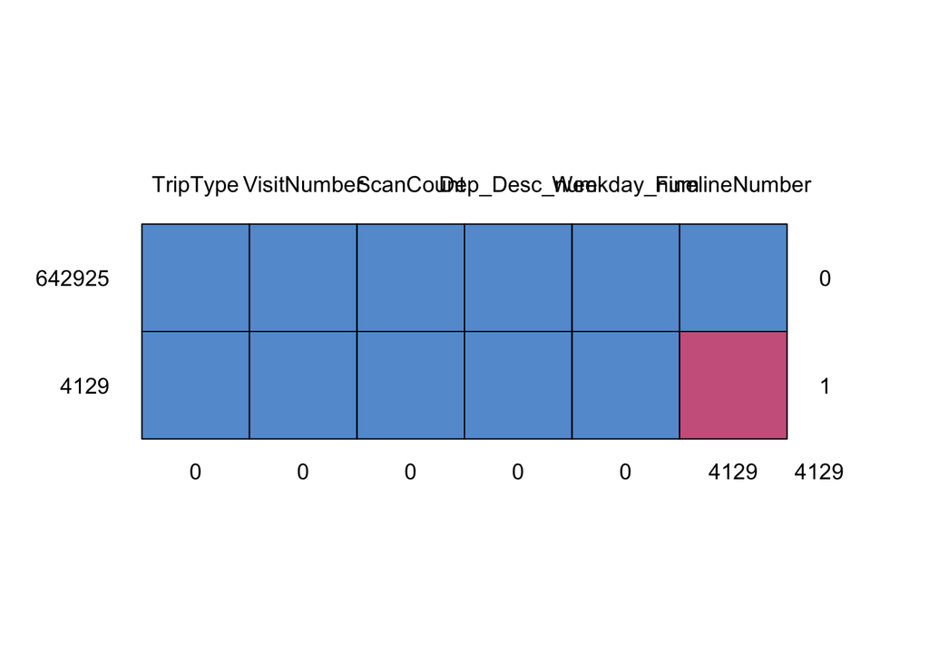

```
##        TripType VisitNumber ScanCount Dep_Desc_num Weekday_num
## 642925        1           1         1            1           1
## 4129          1           1         1            1           1
##               0           0         0            0           0
##        FinelineNumber
## 642925              1    0
## 4129                0    1
##                  4129 4129
```

```r
# md.pattern(Datos_train_tibble) # Donde hay datos faltantes

md.pattern(Datos_train_tibble_exc) # Donde hay datos faltantes
```

[output not shown]

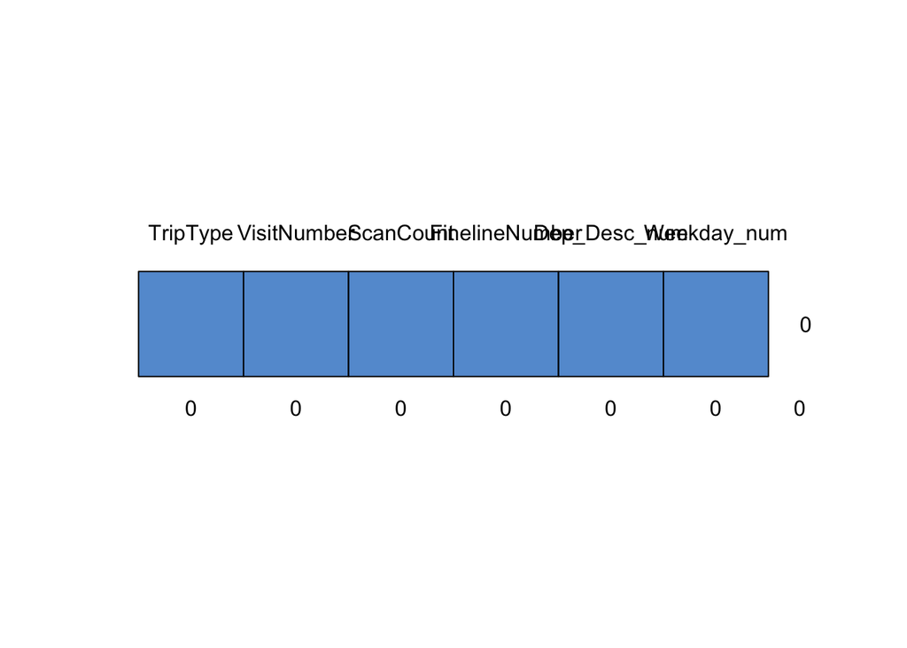

```
##        TripType VisitNumber ScanCount FinelineNumber Dep_Desc_num
## 642925        1           1         1              1            1
##               0           0         0              0            0
##        Weekday_num
## 642925           1 0
##                  0 0
```

```r
md.pattern(Datos_sin_NAs) # Donde hay datos faltantes
```

Tratamiento de datos faltantes por medio de la librería **MICE**.

```r
# Imputación de datos

# Dato_sin <- Datos_train_tibble[-4]
# glimpse(Dato_sin)
#
# Data_prelimpia <- mice(Dato_sin, m = 1, maxit = 2, meth = 'pmm', seed = 242450)
#
# mice.impute.fastpmm(Dato_sin, donors = 5, type = 1, ridge = 1e-05,
#   version = "", ...)

Data_prelimpia <- mice(Datos_train_tibble_exc, m = 1, maxit = 2, meth = 'pmm', seed = 242)
```

```
##  /\     /\
## {  `---'  }
## {  O   O  }
## ==>  V <==  No need for mice. This data set is completely observed.
##  \  \|/  /
##   `-----'
```

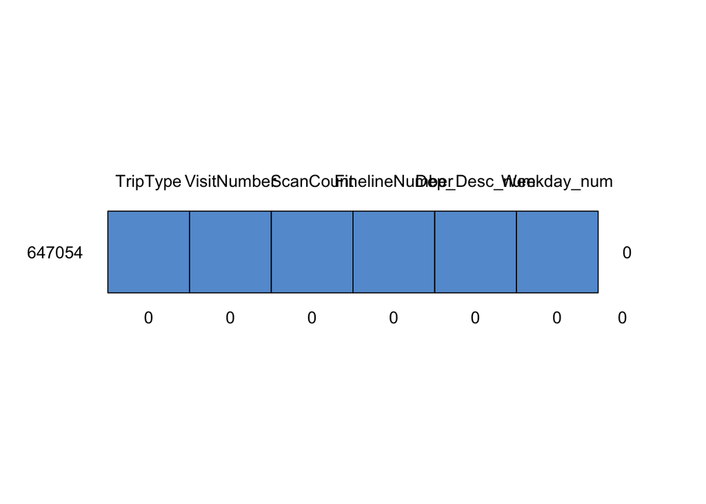

```
##        TripType VisitNumber ScanCount FinelineNumber Dep_Desc_num
## 647054        1           1         1              1            1
##               0           0         0              0            0
##        Weekday_num
## 647054           1 0
##                  0 0
```

```r
train_data <- complete(Data_prelimpia,1)  # Finalmente se modifica la base de datos

# Corroboración de la imputación
md.pattern(train_data)
```

```r
# nas <- apply(Datos_train_tibble, 1,function(x) sum(is.na(x)))
# sum(nas)   # Total de datos faltantes
```

```r
summary(Datos_train_tibble)
```

Ahora, veremos la correlación de las variables numéricas entre sí para encontrar patrones o si las variables son explicativas entre ellas.

```r
round(cor(select(Datos_sin_NAs,TripType,VisitNumber, ScanCount,FinelineNumber)),2)
```

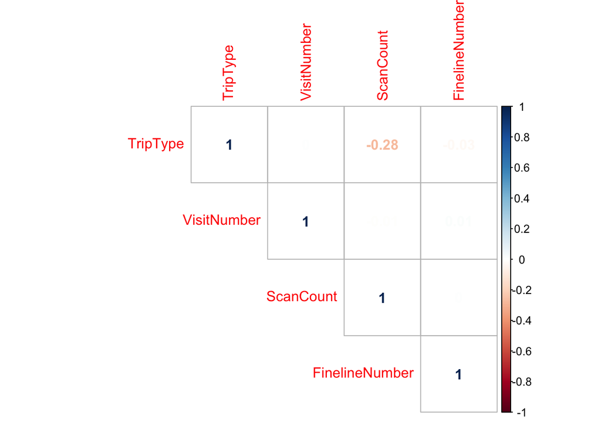

```r
# correlacion <- round(cor(select(train_data,TripType, VisitNumber, Weekday_num, ScanCount,FinelineNumber, Dep_Desc_num)),2)
# corrplot(correlacion, method="number", type="upper")


correlacion <- round(cor(select(Datos_sin_NAs,TripType, VisitNumber, ScanCount,FinelineNumber)),2)
corrplot(correlacion, method="number", type="upper")
```

No hay variables fuertemente correlacionadas para considerar.

```r
plot_corr <- train_data%>%
  select(TripType, VisitNumber, Weekday_num, ScanCount,FinelineNumber, Dep_Desc_num)
ggpairs(plot_corr,diag=list(continuous='densityDiag'))
```

Generación de archivo .csv para evaluar

```r
write.csv(train_data,"/Users/mac/Downloads/train_data.csv", row.names = FALSE)

write.csv(Datos_sin_NAs,"/Users/mac/Downloads/datos_sin_NAs.csv", row.names = FALSE)
```

Comparación de las variables *ScanCount*, *FinelineNumber* y *Weekday*.

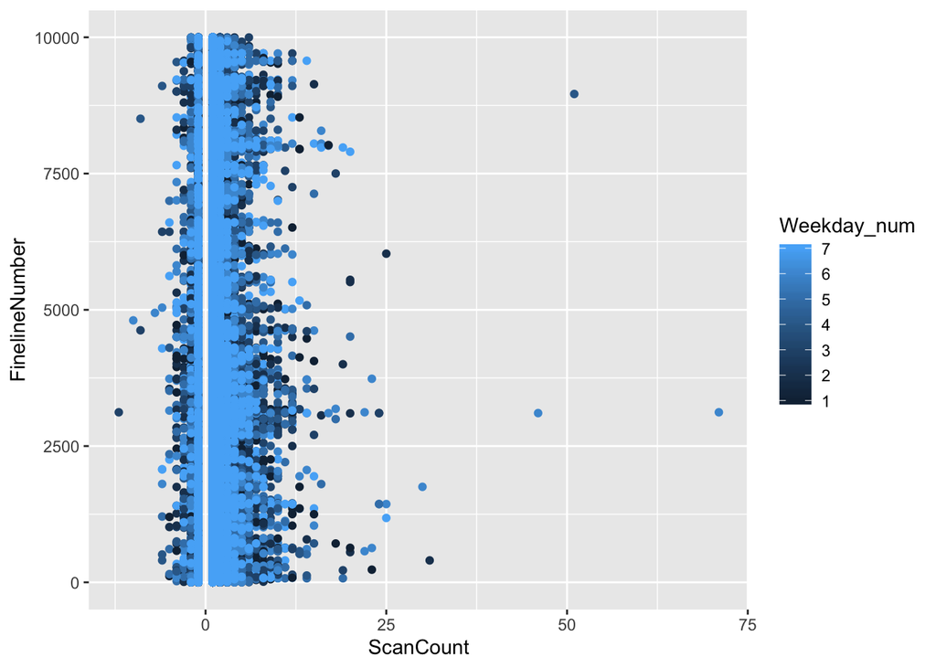

```r
ggplot(data = train_data) +
  geom_point(mapping = aes(x = ScanCount, y = FinelineNumber, color = Weekday_num))
```

No arrojó información relevante.

**Histogramas**

A continuación, se presentan cómo están distribuidos los datos de las variables.

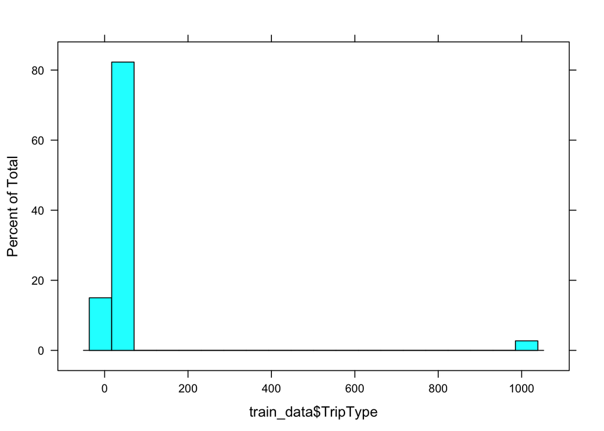

```r
histogram(train_data$TripType)
```

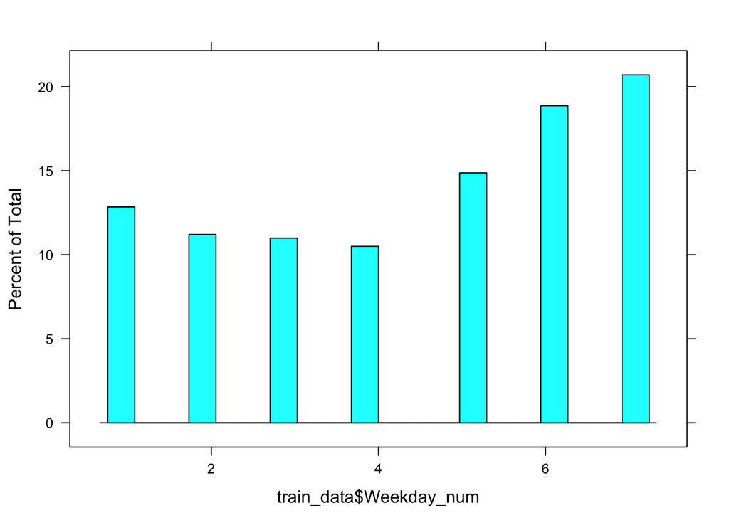

```r
histogram(train_data$Weekday_num)
```

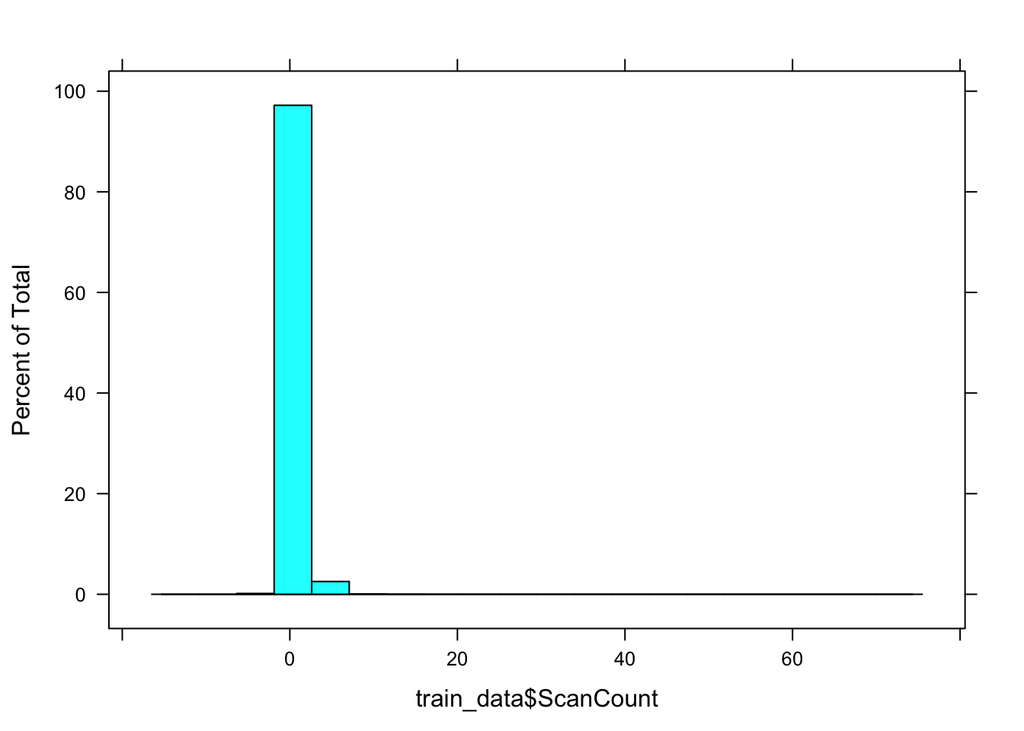

```r
histogram(train_data$ScanCount)
```

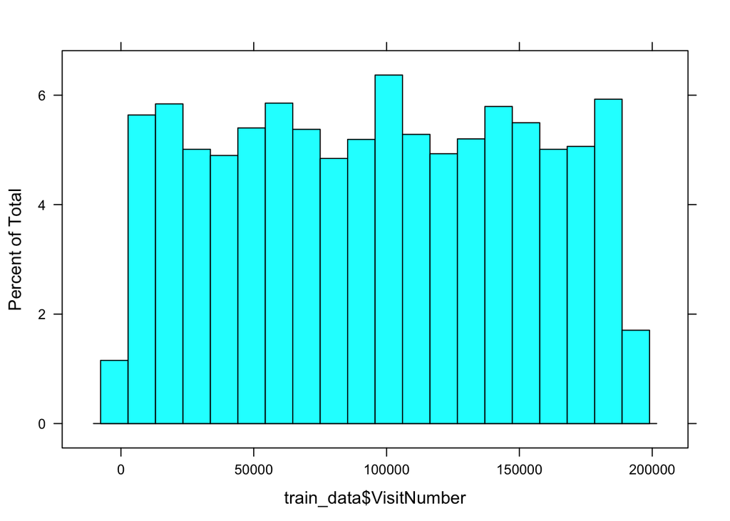

```r
histogram(train_data$VisitNumber)
```

### Análisis ROC y de Componentes Principales

**Análisis de ROC para determinar qué variables se pueden elegir para el modelo**

Con los siguientes análisis se podrá determinar cuáles variables son importantes como explicadoras de nuestra variable de interés.

```r
c1 = roc(train_data$TripType ~ train_data$VisitNumber)
ci.auc(c1)
```

```
## 95% CI: 0.5192-0.5596 (DeLong)
```

```r
c1$auc # Area de la curva de ROC  0.5394
```

```
## Area under the curve: 0.5394
```

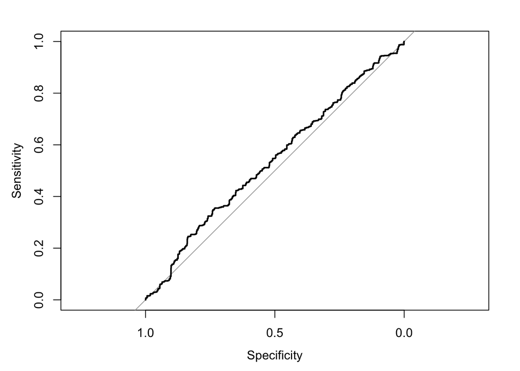

```r
plot(c1)
```

```r
c2 = roc(train_data$TripType ~ train_data$ScanCount)
ci.auc(c2)
```

```
## 95% CI: 0.5105-0.5317 (DeLong)
```

```r
c2$auc   # 0.5211
```

```
## Area under the curve: 0.5211
```

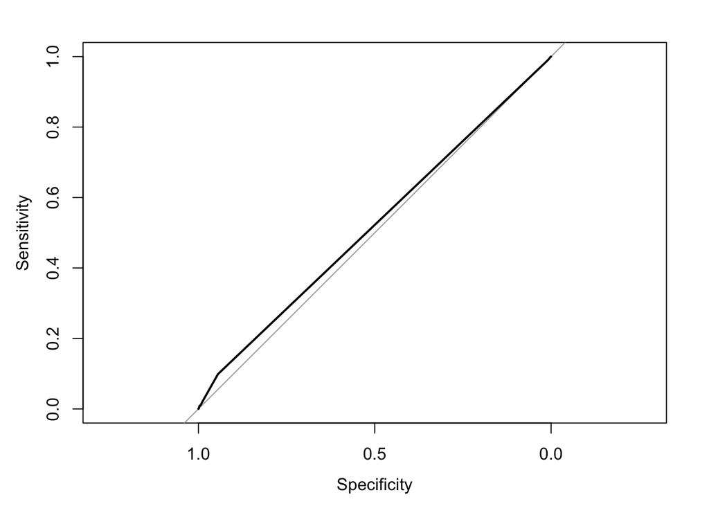

```r
plot(c2)
```

```r
c3 = roc(train_data$TripType ~ train_data$FinelineNumber)
ci.auc(c3)
```

```
## 95% CI: 0.8477-0.876 (DeLong)
```

```r
c3$auc    # 0.8618
```

```
## Area under the curve: 0.8618
```

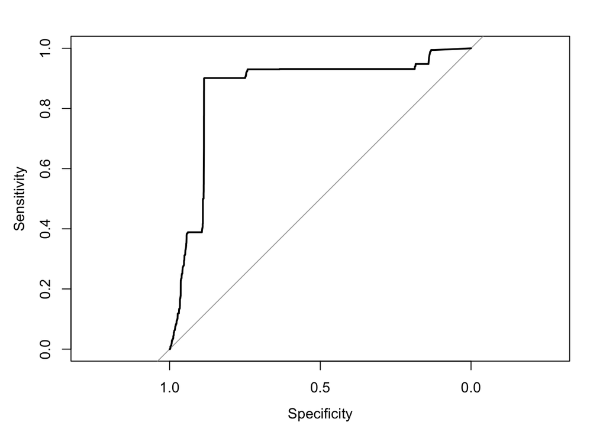

```r
plot(c3)
```

```r
c4 = roc(train_data$TripType ~ train_data$Dep_Desc_num)
ci.auc(c4)
```

```
## 95% CI: 0.808-0.8522 (DeLong)
```

```r
c4$auc   # 0.8301
```

```
## Area under the curve: 0.8301
```